# Applied Example: Estimating reliability of reinforcement learning parameters using data from Pike et al 2026

Author

Giacomo Bignardi

Claude Code was used to prepare the first draft of this document, which was later checked and edited.

# Background

All data from this script comes from Pike, A. C., … Roiser, J. P. (2026). The recoverability, reliability, and generalizability of reward processing parameters and relation to mental health symptoms. Psychological Medicine, 56, e238. doi:10.1017/S0033291726105340.

The [models](https://osf.io/p648q/overview) and [datasets](https://osf.io/kde4b/files/osfstorage) are available on the Open Science Framework. To download the models, you may need to press the “Models” tab in Files Preview.

We use data from the Fluctuating Bandit task (task A).

Rather than using the custom Stan model that the authors used, this notebook uses the `bandit4arm_4par()` function from [`hBayesDM`](https://github.com/CCS-Lab/hBayesDM). This is a hierarchical Bayesian implementation of the 4-parameter model from Seymour, Daw, Roiser, Dayan, & Dolan ([2012](https://www.jneurosci.org/content/32/17/5833)), which is run using a cmdstanr backend. The Stan code for the `bandit4arm_4par()` model is printed in full in the appendix below, alongside a walkthrough of how it works.

# Setup

Analyses are run inside the [`bignardig/tidyverse461`](https://hub.docker.com/r/bignardig/tidyverse461) Docker container - which includes all dependencies except the cmdstan install (v2.39.0). The models were fitted with the `v5` tag of the container; this notebook is rendered with `v6`, which differs only in shipping the newer version of `gbtoolbox`, in which the `reliability()` function has been renamed `rmu()` (the old name still works, with a deprecation warning).

The script `02_01_pike_2026_fit_bandit_models.R` fits the main Bayesian models to time 1 and time 2 separately. It models only the N = 115 subjects who completed **both** sessions (the matched test-retest subsample, not the full N = 547 sample).

The script `02_01_pike_2026_fit_bandit_splithalf_models.R` fits the Bayesian models four times, splitting the data at each timepoint into halves to estimate split-half reliability at each time point. It models only the N = 115 subjects who completed **both** sessions.

The script `02_01_pike_2026_fit_bandit_fullsample.R` fits the Bayesian model to the **full (N = 547) dataset** and also to split-half datasets to estimate RMU and split-half reliability on the full sample.

Run the three fitting scripts once, in order, before rendering this notebook (from the `applied_example_pike/` directory, e.g. inside the `bignardig/tidyverse461:v5` or `v6` container):

```bash
Rscript 02_01_pike_2026_fit_bandit_models.R
Rscript 02_01_pike_2026_fit_bandit_splithalf_models.R
Rscript 02_01_pike_2026_fit_bandit_fullsample.R
```

```r
rm(list = ls())
library(gbtoolbox)
library(hBayesDM)
library(cmdstanr)
library(bayesplot)
library(tidyverse)
library(gt)

data_dir = file.path("data", "pike_2026")
subj_pars = c("Arew", "Apun", "R", "P")
hyper_pars = c("mu_pr", "sigma")
```

# Data

A look at the raw data files behind this notebook

## Raw trial-level exports

`bandit.csv` / `bandit2.csv` are the authors’ raw per-trial exports for session 1 / session 2 (one row per trial). I’ve filtered down to the columns actually used for modelling.

```r
setwd("..") # set the working directory to the parent folder which has /data/

bandit_model_cols = c("id", "trial_nr", "is_gain", "is_loss", "response")

bandit_raw_t1 = read_csv(file.path(data_dir, "bandit.csv"), show_col_types = FALSE) %>%
  select(all_of(bandit_model_cols))
bandit_raw_t2 = read_csv(file.path(data_dir, "bandit2.csv"), show_col_types = FALSE) %>%
  select(all_of(bandit_model_cols))
```

Time 1

```r
rmarkdown::paged_table(bandit_raw_t1, options = list(rows.print = 25, cols.print = ncol(bandit_raw_t1)))
```

| id | trial_nr | is_gain | is_loss | response |
| --- | --- | --- | --- | --- |
| 57 | 0 | 1 | 0 | 4 |
| 57 | 1 | 1 | 0 | 2 |
| 57 | 2 | 0 | 0 | 1 |
| 57 | 3 | 0 | 0 | 3 |
| 57 | 4 | 0 | 0 | 2 |
| 57 | 5 | 1 | 0 | 4 |
| 57 | 6 | 0 | 0 | 4 |
| 57 | 7 | 0 | 1 | 2 |
| 57 | 8 | 0 | 1 | 1 |
| 57 | 9 | 0 | 1 | 4 |

[output cut: 9990 more lines]

Time 2

```r
rmarkdown::paged_table(bandit_raw_t2, options = list(rows.print = 25, cols.print = ncol(bandit_raw_t2)))
```

| id | trial_nr | is_gain | is_loss | response |
| --- | --- | --- | --- | --- |
| 57 | 0 | 1 | 0 | 2 |
| 57 | 1 | 1 | 0 | 2 |
| 57 | 2 | 0 | 0 | 2 |
| 57 | 3 | 0 | 0 | 2 |
| 57 | 4 | 1 | 0 | 2 |
| 57 | 5 | 1 | 0 | 2 |
| 57 | 6 | 0 | 0 | 2 |
| 57 | 7 | 0 | 0 | 2 |
| 57 | 8 | 0 | 0 | 2 |
| 57 | 9 | 0 | 1 | 2 |

[output cut: 9990 more lines]

## hBayesDM-ready data frames

`hBayesDM::bandit4arm_4par()` expects one row per trial, with columns `subjID`/`choice`/`gain`/`loss`. `bandit4arm_df()` (`data/pike_2026/utils.R`) builds that row-per-trial data.frame directly from the raw csvs above, for the matched N = 115 subjects that `02_01_pike_2026_fit_bandit_models.R` fits.

```r
setwd("..") # set the working directory to the parent folder which has /data/

source(file.path(data_dir, "utils.R")) # provides bandit4arm_df()

bandit4arm_df
```

```
function (data, ids = NULL)
{
    if (!is.null(ids))
        data <- data %>% filter(id %in% ids)
    data %>% arrange(id, trial_nr) %>% group_by(id, trial_nr) %>%
        slice_tail(n = 1) %>% ungroup() %>% transmute(subjID = id,
        choice = response, gain = is_gain, loss = is_loss)
}
```

```r
ids_t2_preview = bandit_raw_t2 %>% distinct(id) %>% arrange(id) %>% pull(id)
ids_t1_preview = bandit_raw_t1 %>% filter(id %in% ids_t2_preview) %>% distinct(id) %>% arrange(id) %>% pull(id)

bandit_df_t1 = bandit4arm_df(bandit_raw_t1, ids_t1_preview)
bandit_df_t2 = bandit4arm_df(bandit_raw_t2, ids_t2_preview)

rmarkdown::paged_table(bandit_df_t1, options = list(rows.print = 25, cols.print = ncol(bandit_df_t1)))
```

| subjID | choice | gain | loss |
| --- | --- | --- | --- |
| 16 | 3 | 1 | 0 |
| 16 | 4 | 0 | 0 |
| 16 | 1 | 0 | 0 |
| 16 | 3 | 0 | 0 |
| 16 | 2 | 0 | 1 |
| 16 | 4 | 0 | 1 |
| 16 | 3 | 0 | 0 |
| 16 | 1 | 0 | 0 |
| 16 | 4 | 0 | 1 |
| 16 | 2 | 0 | 0 |

[output cut: 9990 more lines]

## Load saved fits

```r
setwd("..") # set the working directory to the parent folder which has /data/

fits_dir = file.path(data_dir, "model_fits")

if (!file.exists(file.path(fits_dir, "fit_bandit4arm4par_t1.RDS"))) {
  stop("No saved fits found. Run 02_01_pike_2026_fit_bandit_models.R first.")
}
if (!file.exists(file.path(fits_dir, "fit_bandit4arm4par_fullsample.RDS"))) {
  stop("No full-sample fit found. Run 02_01_pike_2026_fit_bandit_fullsample.R first.")
}
if (!file.exists(file.path(fits_dir, "fit_bandit4arm4par_t1_first.RDS"))) {
  stop("No split-half fits found. Run 02_01_pike_2026_fit_bandit_splithalf_models.R first.")
}
if (!file.exists(file.path(fits_dir, "fit_bandit4arm4par_fullsample_first.RDS"))) {
  stop("No full-sample split-half fits found. Run 02_01_pike_2026_fit_bandit_fullsample.R first.")
}

# retest sample (N = 115), time 1 / time 2
ids_t1 = readRDS(file.path(fits_dir, "bandit_ids_t1t2.RDS"))
ids_t2 = ids_t1 # same 115 subjects, same order -- enforced when the fit data.frames were built

fit_bandit_t1 = readRDS(file.path(fits_dir, "fit_bandit4arm4par_t1.RDS"))
fit_bandit_t2 = readRDS(file.path(fits_dir, "fit_bandit4arm4par_t2.RDS"))

# full T1 sample (N = 547)
ids_all = readRDS(file.path(fits_dir, "bandit_ids_all.RDS"))
fit_bandit_all = readRDS(file.path(fits_dir, "fit_bandit4arm4par_fullsample.RDS"))

# retest sample split-half (N = 115), time 1 / time 2
ids_splithalf = readRDS(file.path(fits_dir, "bandit_splithalf_ids.RDS"))

fit_bandit_t1_first  = readRDS(file.path(fits_dir, "fit_bandit4arm4par_t1_first.RDS"))
fit_bandit_t1_second = readRDS(file.path(fits_dir, "fit_bandit4arm4par_t1_second.RDS"))
fit_bandit_t2_first  = readRDS(file.path(fits_dir, "fit_bandit4arm4par_t2_first.RDS"))
fit_bandit_t2_second = readRDS(file.path(fits_dir, "fit_bandit4arm4par_t2_second.RDS"))

# full T1 sample split-half (N = 547)
fit_bandit_fullsample_first  = readRDS(file.path(fits_dir, "fit_bandit4arm4par_fullsample_first.RDS"))
fit_bandit_fullsample_second = readRDS(file.path(fits_dir, "fit_bandit4arm4par_fullsample_second.RDS"))
```

# Diagnostics

We fit `bandit4arm_4par()` nine times across this notebook – the T1/T2 retest-sample fits, the full T1 sample, and split-half fits for each of those three – so before trusting any of the reliability estimates below, we check convergence across all nine, not just the two headline T1/T2 fits.

```r
all_fits = list(
  "T1 (retest, N = 115)"          = fit_bandit_t1,
  "T2 (retest, N = 115)"          = fit_bandit_t2,
  "Full T1 sample (N = 547)"      = fit_bandit_all,
  "T1 first-half (N = 115)"       = fit_bandit_t1_first,
  "T1 second-half (N = 115)"      = fit_bandit_t1_second,
  "T2 first-half (N = 115)"       = fit_bandit_t2_first,
  "T2 second-half (N = 115)"      = fit_bandit_t2_second,
  "Full T1 first-half (N = 547)"  = fit_bandit_fullsample_first,
  "Full T1 second-half (N = 547)" = fit_bandit_fullsample_second
)

diag_pars  = c(hyper_pars, subj_pars)

rhat_threshold = 1.01
ess_threshold  = 400 # cmdstanr's own rule of thumb: bulk/tail ESS < 100 per chain (400 across our 4 chains)
```

## Sampler diagnostics (divergences, treedepth, E-BFMI)

```r
sampler_diag = imap_dfr(all_fits, function(fit, label) {
  d = fit$diagnostic_summary()
  tibble(
    model           = label,
    n_divergent     = sum(d$num_divergent),
    n_max_treedepth = sum(d$num_max_treedepth),
    min_ebfmi       = min(d$ebfmi)
  )
})

sampler_diag %>%
  gt() %>%
  fmt_number(columns = min_ebfmi, decimals = 2) %>%
  tab_style(
    style     = list(cell_fill(color = "#f8d7da"), cell_text(weight = "bold")),
    locations = cells_body(columns = n_divergent, rows = n_divergent > 0)
  ) %>%
  tab_style(
    style     = list(cell_fill(color = "#f8d7da"), cell_text(weight = "bold")),
    locations = cells_body(columns = n_max_treedepth, rows = n_max_treedepth > 0)
  ) %>%
  tab_style(
    style     = list(cell_fill(color = "#f8d7da"), cell_text(weight = "bold")),
    locations = cells_body(columns = min_ebfmi, rows = min_ebfmi < 0.3)
  )
```

| model | n_divergent | n_max_treedepth | min_ebfmi |
| --- | --- | --- | --- |
| T1 (retest, N = 115) | 0 | 0 | 0.70 |
| T2 (retest, N = 115) | 0 | 0 | 0.70 |
| Full T1 sample (N = 547) | 0 | 0 | 0.65 |
| T1 first-half (N = 115) | 0 | 0 | 0.71 |
| T1 second-half (N = 115) | 0 | 0 | 0.70 |
| T2 first-half (N = 115) | 0 | 0 | 0.70 |
| T2 second-half (N = 115) | 0 | 0 | 0.72 |
| Full T1 first-half (N = 547) | 0 | 0 | 0.65 |
| Full T1 second-half (N = 547) | 0 | 0 | 0.67 |

Any red cell above means one of the nine fits needs a closer look before its reliability numbers are trusted.

## Rhat / ESS by parameter, across all models

Rather than eyeballing `summary()` output fit-by-fit, we collapse each fit’s per-subject `rhat`/`ess_bulk`/`ess_tail` down to one row per parameter family (`mu_pr`, `sigma`, `Arew`, `Apun`, `R`, `P`) – taking the worst (max rhat / min ESS) across subjects within that family – so a single bad subject-level parameter can’t hide inside a fit-wide average. Flagged cells breach the conventional rhat > 1.01 / ESS < 400 thresholds.

```r
param_diag = imap_dfr(all_fits, function(fit, label) {
  fit$summary(variables = diag_pars) %>%
    mutate(parameter = str_extract(variable, "^[^\\[]+")) %>%
    group_by(parameter) %>%
    summarise(
      max_rhat     = max(rhat, na.rm = TRUE),
      min_ess_bulk = min(ess_bulk, na.rm = TRUE),
      min_ess_tail = min(ess_tail, na.rm = TRUE),
      .groups = "drop"
    ) %>%
    mutate(model = label, .before = 1)
}) %>%
  mutate(parameter = factor(parameter, levels = diag_pars))

param_diag %>%
  gt(groupname_col = "model") %>%
  fmt_number(columns = max_rhat, decimals = 3) %>%
  fmt_number(columns = c(min_ess_bulk, min_ess_tail), decimals = 0) %>%
  tab_style(
    style     = list(cell_fill(color = "#f8d7da"), cell_text(weight = "bold")),
    locations = cells_body(columns = max_rhat, rows = max_rhat > rhat_threshold)
  ) %>%
  tab_style(
    style     = list(cell_fill(color = "#f8d7da"), cell_text(weight = "bold")),
    locations = cells_body(columns = min_ess_bulk, rows = min_ess_bulk < ess_threshold)
  ) %>%
  tab_style(
    style     = list(cell_fill(color = "#f8d7da"), cell_text(weight = "bold")),
    locations = cells_body(columns = min_ess_tail, rows = min_ess_tail < ess_threshold)
  )
```

| parameter | max_rhat | min_ess_bulk | min_ess_tail |
| --- | --- | --- | --- |
| T1 (retest, N = 115) |  |  |  |
| Apun | 1.001 | 6,821 | 4,016 |
| Arew | 1.003 | 2,200 | 573 |
| P | 1.001 | 6,362 | 3,972 |
| R | 1.003 | 2,097 | 616 |
| mu_pr | 1.004 | 1,462 | 3,701 |
| sigma | 1.002 | 3,018 | 6,889 |
| T2 (retest, N = 115) |  |  |  |
| Apun | 1.001 | 6,495 | 6,922 |
| Arew | 1.001 | 6,911 | 5,094 |
| P | 1.001 | 5,516 | 6,279 |
| R | 1.001 | 7,035 | 4,724 |
| mu_pr | 1.003 | 1,304 | 2,960 |
| sigma | 1.002 | 3,605 | 7,079 |
| Full T1 sample (N = 547) |  |  |  |
| Apun | 1.004 | 1,513 | 2,549 |
| Arew | 1.005 | 655 | 1,718 |
| P | 1.003 | 1,260 | 2,519 |
| R | 1.005 | 675 | 1,993 |
| mu_pr | 1.012 | 441 | 748 |
| sigma | 1.010 | 461 | 852 |
| T1 first-half (N = 115) |  |  |  |
| Apun | 1.001 | 6,855 | 6,475 |
| Arew | 1.002 | 8,360 | 4,231 |
| P | 1.001 | 6,828 | 6,493 |
| R | 1.001 | 7,296 | 4,624 |
| mu_pr | 1.003 | 1,883 | 4,220 |
| sigma | 1.001 | 3,168 | 6,905 |
| T1 second-half (N = 115) |  |  |  |
| Apun | 1.001 | 4,117 | 2,603 |
| Arew | 1.001 | 5,269 | 1,392 |
| P | 1.001 | 4,167 | 3,410 |
| R | 1.001 | 4,867 | 1,717 |
| mu_pr | 1.003 | 1,313 | 3,038 |
| sigma | 1.002 | 2,360 | 4,759 |
| T2 first-half (N = 115) |  |  |  |
| Apun | 1.006 | 1,209 | 1,747 |
| Arew | 1.004 | 1,863 | 2,292 |
| P | 1.006 | 1,261 | 1,562 |
| R | 1.004 | 1,881 | 2,461 |
| mu_pr | 1.009 | 662 | 1,209 |
| sigma | 1.010 | 713 | 1,554 |
| T2 second-half (N = 115) |  |  |  |
| Apun | 1.001 | 4,339 | 5,617 |
| Arew | 1.001 | 4,996 | 3,620 |
| P | 1.001 | 3,901 | 5,121 |
| R | 1.001 | 4,986 | 4,292 |
| mu_pr | 1.005 | 1,286 | 2,903 |
| sigma | 1.002 | 2,006 | 4,022 |
| Full T1 first-half (N = 547) |  |  |  |
| Apun | 1.002 | 2,918 | 984 |
| Arew | 1.002 | 1,585 | 2,857 |
| P | 1.002 | 3,680 | 3,399 |
| R | 1.003 | 1,619 | 2,811 |
| mu_pr | 1.005 | 922 | 1,797 |
| sigma | 1.007 | 927 | 2,007 |
| Full T1 second-half (N = 547) |  |  |  |
| Apun | 1.001 | 2,361 | 3,380 |
| Arew | 1.003 | 964 | 1,280 |
| P | 1.001 | 3,365 | 2,931 |
| R | 1.003 | 940 | 1,387 |
| mu_pr | 1.006 | 1,266 | 1,816 |
| sigma | 1.005 | 1,511 | 2,481 |

## Parameters with consistently poor convergence

Collapsing the table above across models: for each parameter family, the worst rhat/ESS seen in *any* of the nine fits, which fit produced it, and how many fits flag it – so a parameter that’s borderline everywhere is distinguishable from one bad fit dragging down an otherwise clean parameter.

```r
param_summary = param_diag %>%
  group_by(parameter) %>%
  summarise(
    worst_rhat            = max(max_rhat),
    worst_rhat_model       = model[which.max(max_rhat)],
    worst_ess_bulk         = min(min_ess_bulk),
    worst_ess_bulk_model   = model[which.min(min_ess_bulk)],
    n_models_rhat_flagged = sum(max_rhat > rhat_threshold),
    n_models_ess_flagged  = sum(min_ess_bulk < ess_threshold),
    .groups = "drop"
  ) %>%
  arrange(desc(worst_rhat))

param_summary %>%
  gt() %>%
  fmt_number(columns = worst_rhat, decimals = 3) %>%
  fmt_number(columns = worst_ess_bulk, decimals = 0) %>%
  tab_style(
    style     = list(cell_fill(color = "#f8d7da"), cell_text(weight = "bold")),
    locations = cells_body(columns = n_models_rhat_flagged, rows = n_models_rhat_flagged > 0)
  ) %>%
  tab_style(
    style     = list(cell_fill(color = "#f8d7da"), cell_text(weight = "bold")),
    locations = cells_body(columns = n_models_ess_flagged, rows = n_models_ess_flagged > 0)
  )
```

| parameter | worst_rhat | worst_rhat_model | worst_ess_bulk | worst_ess_bulk_model | n_models_rhat_flagged | n_models_ess_flagged |
| --- | --- | --- | --- | --- | --- | --- |
| mu_pr | 1.012 | Full T1 sample (N = 547) | 441 | Full T1 sample (N = 547) | 1 | 0 |
| sigma | 1.010 | Full T1 sample (N = 547) | 461 | Full T1 sample (N = 547) | 1 | 0 |
| P | 1.006 | T2 first-half (N = 115) | 1,260 | Full T1 sample (N = 547) | 0 | 0 |
| Apun | 1.006 | T2 first-half (N = 115) | 1,209 | T2 first-half (N = 115) | 0 | 0 |
| R | 1.005 | Full T1 sample (N = 547) | 675 | Full T1 sample (N = 547) | 0 | 0 |
| Arew | 1.005 | Full T1 sample (N = 547) | 655 | Full T1 sample (N = 547) | 0 | 0 |

## Subject-level checks

The per-parameter table above takes the *worst* subject in each fit – it can’t tell us whether the same handful of subjects are consistently unidentifiable (worth flagging, or excluding, individually) or whether the problem is spread thinly across many different subjects (more likely a sampler-tuning issue than a subject-data issue). We rebuild the same rhat/ESS check but keep every subject, then rank subjects by how often they’re flagged across all the (fit x parameter) combinations they appear in.

```r
all_ids = list(
  "T1 (retest, N = 115)"          = ids_t1,
  "T2 (retest, N = 115)"          = ids_t2,
  "Full T1 sample (N = 547)"      = ids_all,
  "T1 first-half (N = 115)"       = ids_splithalf,
  "T1 second-half (N = 115)"      = ids_splithalf,
  "T2 first-half (N = 115)"       = ids_splithalf,
  "T2 second-half (N = 115)"      = ids_splithalf,
  "Full T1 first-half (N = 547)"  = ids_all,
  "Full T1 second-half (N = 547)" = ids_all
)

subject_diag = imap_dfr(all_fits, function(fit, label) {
  ids = all_ids[[label]]
  fit$summary(variables = subj_pars) %>%
    mutate(
      parameter = str_extract(variable, "^[^\\[]+"),
      idx       = as.integer(str_extract(variable, "(?<=\\[)\\d+(?=\\])")),
      id        = ids[idx]
    ) %>%
    select(id, parameter, rhat, ess_bulk, ess_tail) %>%
    mutate(model = label, .before = 1)
}) %>%
  mutate(
    parameter = factor(parameter, levels = subj_pars),
    flagged   = rhat > rhat_threshold | ess_bulk < ess_threshold
  )

subject_flag_summary = subject_diag %>%
  group_by(id) %>%
  summarise(
    n_evaluated    = n(), # how many (fit x parameter) combinations this subject appears in
    n_flagged      = sum(flagged),
    pct_flagged    = n_flagged / n_evaluated,
    worst_rhat     = max(rhat),
    worst_ess_bulk = min(ess_bulk),
    .groups = "drop"
  ) %>%
  arrange(desc(pct_flagged), desc(worst_rhat))

subject_flag_summary %>%
  slice_head(n = 20) %>%
  gt() %>%
  fmt_percent(columns = pct_flagged, decimals = 0) %>%
  fmt_number(columns = worst_rhat, decimals = 3) %>%
  fmt_number(columns = worst_ess_bulk, decimals = 0) %>%
  tab_header(title = "20 subjects flagged most often (rhat > 1.01 or ESS < 400)") %>%
  tab_style(
    style     = list(cell_fill(color = "#f8d7da"), cell_text(weight = "bold")),
    locations = cells_body(columns = pct_flagged, rows = pct_flagged > 0.5)
  )
```

20 subjects flagged most often (rhat > 1.01 or ESS < 400)

| id | n_evaluated | n_flagged | pct_flagged | worst_rhat | worst_ess_bulk |
| --- | --- | --- | --- | --- | --- |
| 145 | 36 | 0 | 0% | 1.006 | 1,222 |
| 279 | 36 | 0 | 0% | 1.005 | 1,209 |
| 180 | 36 | 0 | 0% | 1.005 | 1,371 |
| 527 | 36 | 0 | 0% | 1.005 | 1,287 |
| 71 | 36 | 0 | 0% | 1.005 | 1,573 |
| 456 | 36 | 0 | 0% | 1.005 | 1,534 |
| 186 | 12 | 0 | 0% | 1.005 | 655 |
| 278 | 36 | 0 | 0% | 1.005 | 1,590 |
| 496 | 36 | 0 | 0% | 1.005 | 1,916 |
| 168 | 36 | 0 | 0% | 1.005 | 1,609 |
| 545 | 36 | 0 | 0% | 1.004 | 1,544 |
| 430 | 36 | 0 | 0% | 1.004 | 1,815 |
| 346 | 36 | 0 | 0% | 1.004 | 1,331 |
| 477 | 36 | 0 | 0% | 1.004 | 1,775 |
| 94 | 36 | 0 | 0% | 1.004 | 1,694 |
| 491 | 36 | 0 | 0% | 1.004 | 1,939 |
| 35 | 12 | 0 | 0% | 1.004 | 2,682 |
| 395 | 36 | 0 | 0% | 1.003 | 1,803 |
| 352 | 36 | 0 | 0% | 1.003 | 1,744 |
| 62 | 36 | 0 | 0% | 1.003 | 1,604 |

If the same subject IDs sit at the top of this table across most rows, that points to specific subjects (e.g. near-random responders where learning rates/sensitivities are only weakly identified by the likelihood) rather than a broad sampler problem. The histogram below shows whether flagged subjects are a small concentrated group or spread across the sample:

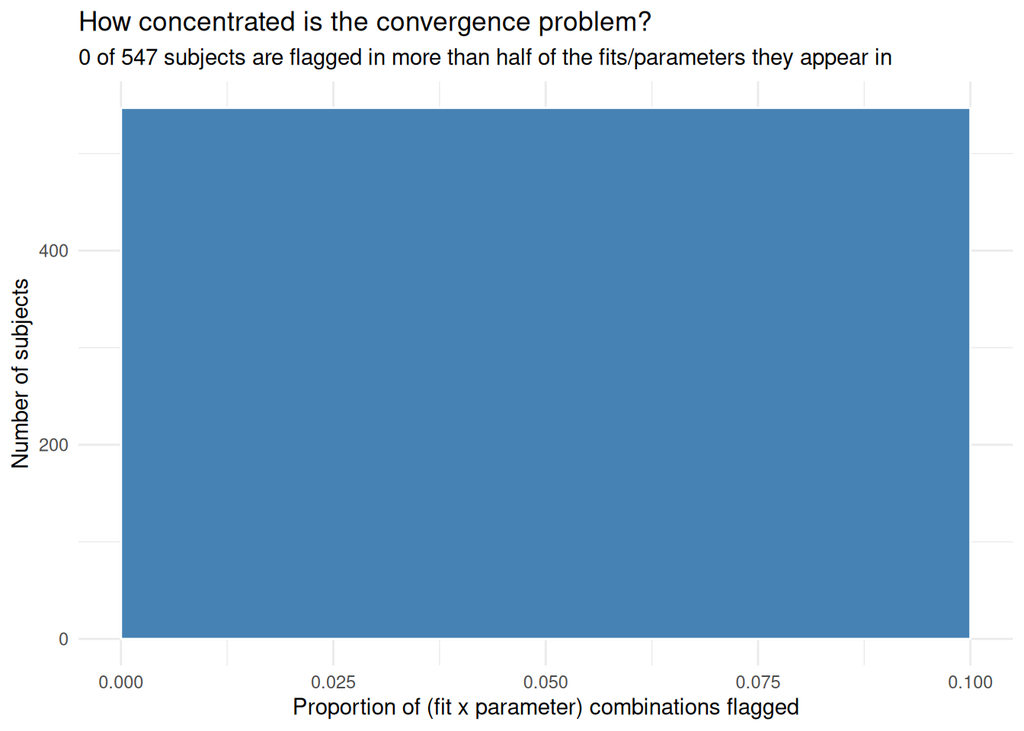

```r
subject_flag_summary %>%
  ggplot(aes(x = pct_flagged)) +
  geom_histogram(binwidth = 0.1, boundary = 0, fill = "steelblue", color = "white") +
  labs(
    x = "Proportion of (fit x parameter) combinations flagged",
    y = "Number of subjects",
    title = "How concentrated is the convergence problem?",
    subtitle = paste0(
      sum(subject_flag_summary$pct_flagged > 0.5), " of ", nrow(subject_flag_summary),
      " subjects are flagged in more than half of the fits/parameters they appear in"
    )
  ) +
  theme_minimal()
```

## Group-level parameter trace plots (T1 / T2 retest fits)

`mu_pr`/`sigma` are the population mean/SD (probit scale) behind `Arew`/`Apun`/`R`/`P`, in that order – i.e. `mu_pr[2]`/`sigma[2]` are what determine where `Apun` gets pulled to and how tightly (see the per-subject posterior density discussion below).

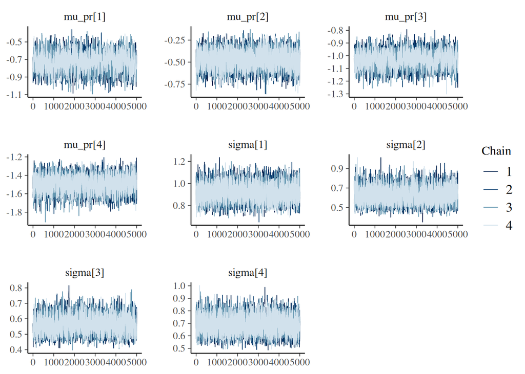

```r
mcmc_trace(fit_bandit_t1$draws(variables = hyper_pars))
```

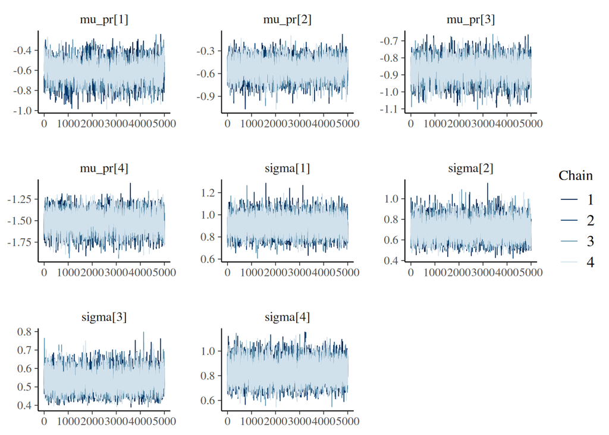

```r
mcmc_trace(fit_bandit_t2$draws(variables = hyper_pars))
```

# Inspect subject-level parameter estimates

## Posterior means

In this section, we extract posterior mean estimates for each subject’s reward learning rate (`Arew`), punishment learning rate (`Apun`), reward sensitivity (`R`) and punishment sensitivity (`P`).

```r
extract_indpars = function(fit, ids, pars = subj_pars) {
  fit$summary(variables = pars) %>% # This gives a long dataframe with the posterior mean/median/quantiles for each parameter in the model
    mutate(
      parameter = str_extract(variable, "^[^\\[]+"),
      idx       = as.integer(str_extract(variable, "(?<=\\[)\\d+(?=\\])")),
      id        = ids[idx]
    ) %>%
    select(id, parameter, mean, sd) %>%
    pivot_wider(id_cols = id, names_from = parameter, values_from = mean)
}

indpars_t1 = extract_indpars(fit_bandit_t1, ids_t1)
indpars_t2 = extract_indpars(fit_bandit_t2, ids_t2)

indpars_t1
```

```
# A tibble: 115 × 5
      id   Arew   Apun     R      P
   <dbl>  <dbl>  <dbl> <dbl>  <dbl>
 1    16 0.257  0.259   2.63  0.805
 2    17 0.768  0.307   9.25  0.106
 3    26 0.258  0.0699 22.7  16.5
 4    27 0.362  0.168   7.31  9.03
 5    32 0.0464 0.509   5.04  1.48
 6    36 0.0747 0.376   3.14  1.60
 7    41 0.636  0.237   2.03  1.73
 8    46 0.286  0.461   6.96  6.29
 9    50 0.220  0.304   7.33  2.81
10    53 0.0772 0.451   2.26  2.32
# ℹ 105 more rows
```

## Posterior densities

Below we show the posterior densities for each subject, separately for each time point.

Here, we use data from the full T1 sample (N = 547)

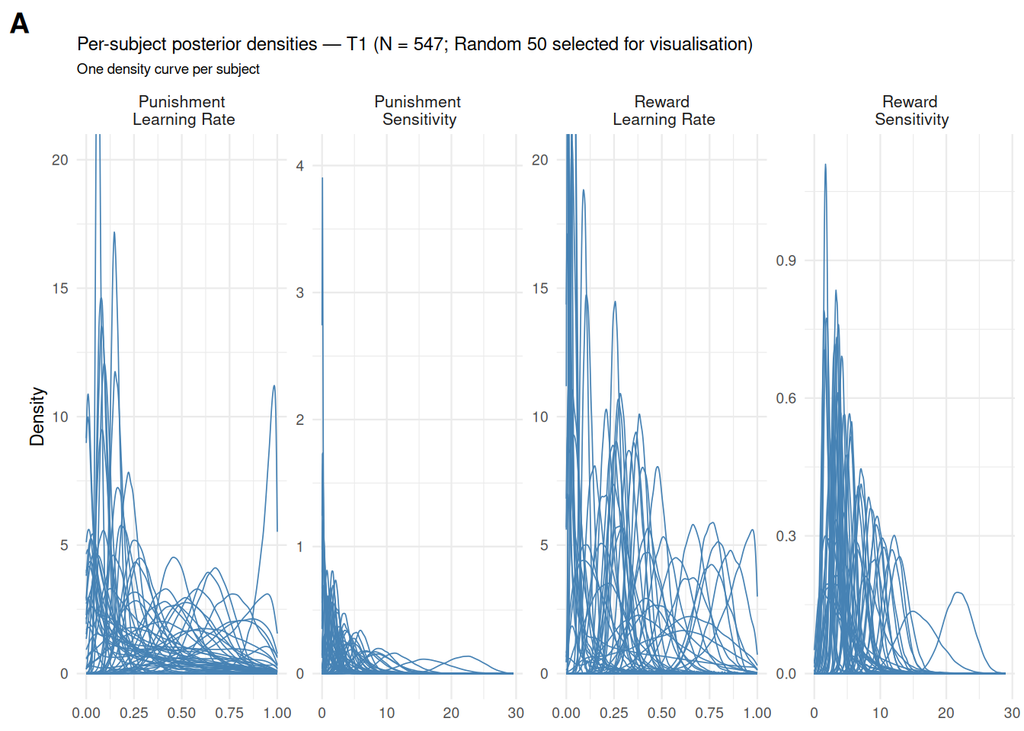

```r
get_draws_long = function(fit, ids, pars = subj_pars) {
  fit$draws(variables = pars, format = "df") %>%
    as_tibble() %>%
    select(-.chain, -.iteration, -.draw) %>%
    pivot_longer(everything(), names_to = "variable", values_to = "value") %>%
    mutate(
      parameter = str_extract(variable, "^[^\\[]+"),
      idx       = as.integer(str_extract(variable, "(?<=\\[)\\d+(?=\\])")),
      id        = ids[idx]
    )
}

plot_subject_densities = function(fit, ids, session_label, pars = subj_pars, ymax_cap = 20) {
  draws_long = get_draws_long(fit, ids, pars) |>
    mutate(
      parameter = case_when(
        parameter == "Arew" ~ "Reward\n Learning Rate",
        parameter == "Apun" ~ "Punishment\n Learning Rate",
        parameter == "R"    ~ "Reward\n Sensitivity",
        parameter == "P"    ~ "Punishment\n Sensitivity"
      )
    )

  # per-facet y upper limit: each subject's own density peak, capped at ymax_cap
  y_scales = draws_long %>%
    group_by(parameter, id) %>%
    summarise(peak = max(density(value)$y), .groups = "drop") %>%
    group_by(parameter) %>%
    summarise(ymax = min(max(peak), ymax_cap), .groups = "drop") %>%
    arrange(parameter) %>%
    pull(ymax) %>%
    purrr::map(~ scale_y_continuous(limits = c(0, .x)))

  draws_long %>%
    ggplot(aes(
      x = value,
      # y = after_stat(scaled),
      group = id)
      ) +
    geom_density(alpha = 0.1, linewidth = 0.3, color = "steelblue") +
    facet_wrap(~parameter, scales = "free", nrow = 1) +
    ggh4x::facetted_pos_scales(y = y_scales) +
    labs(
      title = paste0("Per-subject posterior densities — ", session_label),
      subtitle = "One density curve per subject",
      x = NULL, y = "Density",
      tag = "A"
    ) +
    theme_minimal(base_size = 9) +
    theme(
      plot.title    = element_text(size = 9),
      plot.subtitle = element_text(size = 7),
      strip.text    = element_text(size = 8),
      plot.tag      = element_text(size = 14, face = "bold")
    )
}

plot_subject_densities(fit_bandit_all, ids_all[1:50], "T1 (N = 547; Random 50 selected for visualisation)")
```

```r
ggsave("02_pike_posteriors.png", width = 7, height = 2.5, dpi = 800)

# plot_subject_densities(fit_bandit_fullsample_second, ids_t2, "T2")
```

## Posterior Correlations Between Draws

RMU treats each posterior draw as if it were a separate “measurement” of every subject, and reliability comes from how consistently subjects are ranked from one draw to the next. To build intuition for that, below we pick a few random pairs of draws (columns of the posterior draws matrix) for each parameter and simply correlate subjects’ values on one draw against their values on the other.

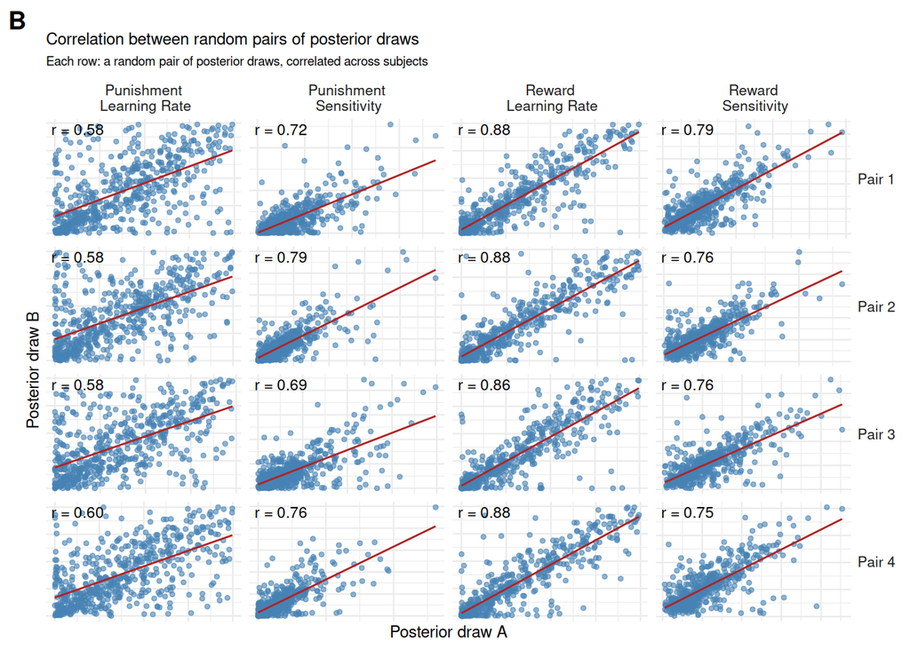

```r
get_draws_matrix_raw = function(fit, ids, par) {
  m = unclass(fit$draws(variables = par, format = "matrix")) # draws x N, plain matrix
  colnames(m) = ids
  t(m) # N x draws
}

get_draw_pair_correlations = function(fit, ids, pars = subj_pars, n_pairs = 4, seed = 1) {
  set.seed(seed)
  map_dfr(pars, function(p) {
    m = get_draws_matrix_raw(fit, ids, p) # N x draws
    n_draws = ncol(m)
    map_dfr(seq_len(n_pairs), function(i) {
      draw_idx = sample(n_draws, 2)
      tibble(
        parameter = p,
        pair      = paste0("Pair ", i),
        draw_a    = m[, draw_idx[1]],
        draw_b    = m[, draw_idx[2]]
      )
    })
  })
}

draw_pairs = get_draw_pair_correlations(fit_bandit_all, ids_all, subj_pars, n_pairs = 4) |>
  mutate(
    parameter = case_when(
      parameter == "Arew" ~ "Reward\n Learning Rate",
      parameter == "Apun" ~ "Punishment\n Learning Rate",
      parameter == "R"    ~ "Reward\n Sensitivity",
      parameter == "P"    ~ "Punishment\n Sensitivity"
    ),
    pair = fct_inorder(pair)
  )

draw_pair_cors = draw_pairs |>
  group_by(parameter, pair) |>
  summarise(label = paste0("r = ", sprintf("%.2f", cor(draw_a, draw_b))), .groups = "drop")

draw_pairs |>
  ggplot(aes(x = draw_a, y = draw_b)) +
  geom_point(alpha = 0.6, size = 1, color = "steelblue") +
  geom_smooth(method = "lm", se = FALSE, color = "firebrick", linewidth = 0.5) +
  geom_text(
    data = draw_pair_cors, aes(label = label),
    x = -Inf, y = Inf, hjust = -0.1, vjust = 1.4, size = 3, inherit.aes = FALSE
  ) +
  ggh4x::facet_grid2(pair ~ parameter, scales = "free", independent = "all") +
  labs(
    title = "Correlation between random pairs of posterior draws",
    subtitle = "Each row: a random pair of posterior draws, correlated across subjects",
    x = "Posterior draw A", y = "Posterior draw B",
    tag = "B"
  ) +
  theme_minimal(base_size = 9) +
  theme(
    plot.title    = element_text(size = 9),
    plot.subtitle = element_text(size = 7),
    strip.text    = element_text(size = 8),
    strip.text.y  = element_text(angle = 0),
    plot.tag      = element_text(size = 14, face = "bold"),
    axis.text.x   = element_blank(),
    axis.text.y   = element_blank(),
    axis.ticks    = element_blank()
  )
```

```r
ggsave("02_pike_draw_pair_correlations.png", width = 7, height = 7, dpi = 800)
```

# Test-retest reliability

Correlate each subject’s posterior-mean parameter estimate across the two sessions.

```r
stopifnot(identical(indpars_t1$id, indpars_t2$id))

testretest = map_dfr(subj_pars, function(p) {
  ct = cor.test(indpars_t1[[p]], indpars_t2[[p]])
  r  = unname(ct$estimate)
  tibble(
    parameter = p,
    method    = "Test-Retest (N = 115)",
    estimate  = r,
    se        = sqrt((1 - r^2) / ct$parameter), # SE of Pearson r implied by the t-test df (matches cor.test's statistic)
    lower     = ct$conf.int[1],
    upper     = ct$conf.int[2],
    width     = ct$conf.int[2] - ct$conf.int[1]
  )
})

testretest |>
  gt() |>
  fmt_number(decimals = 3)
```

| parameter | method | estimate | se | lower | upper | width |
| --- | --- | --- | --- | --- | --- | --- |
| Arew | Test-Retest (N = 115) | 0.483 | 0.082 | 0.328 | 0.612 | 0.283 |
| Apun | Test-Retest (N = 115) | 0.418 | 0.085 | 0.255 | 0.559 | 0.304 |
| R | Test-Retest (N = 115) | 0.636 | 0.073 | 0.512 | 0.733 | 0.221 |
| P | Test-Retest (N = 115) | 0.357 | 0.088 | 0.186 | 0.507 | 0.321 |

# RMU

`gbtoolbox::rmu()` estimates a *within-session* reliability (RMU) using the posterior samples from each subject. The saved fits are plain `cmdstanr` fit objects (rather than `hBayesDM` objects, which `rmu()` can also take directly – see the RMU bandit tutorial), so here we extract the posterior-draw matrices ourselves.

## Retest sample (N = 115)

```r
get_draws_matrix = function(fit, ids, par) {
  m = fit$draws(variables = par, format = "matrix") # draws x N
  colnames(m) = ids
  t(m) # N x draws
}

extract_rmu = function(fit, ids, session_label, pars = subj_pars) {
  map_dfr(pars, function(p) {
    # browser()
    rel = rmu(get_draws_matrix(fit, ids, p))
    tibble(
      parameter = p,
      method    = paste0("RMU (", session_label, ")"),
      estimate  = rel$hdci$rmu_estimate,
      se        = sd(rel$reliability_posterior_draws), # posterior SD of the RMU draws
      lower     = rel$hdci$hdci_lowerbound,
      upper     = rel$hdci$hdci_upperbound,
      width     = rel$hdci$hdci_upperbound - rel$hdci$hdci_lowerbound
    )
  })
}

rmu_retest = bind_rows(
  extract_rmu(fit_bandit_t1, ids_t1, "T1, N = 115"),
  extract_rmu(fit_bandit_t2, ids_t2, "T2, N = 115")
)

rmu_retest |>
  gt() |>
  fmt_number(decimals = 3)
```

| parameter | method | estimate | se | lower | upper | width |
| --- | --- | --- | --- | --- | --- | --- |
| Arew | RMU (T1, N = 115) | 0.853 | 0.037 | 0.779 | 0.919 | 0.140 |
| Apun | RMU (T1, N = 115) | 0.484 | 0.077 | 0.336 | 0.629 | 0.294 |
| R | RMU (T1, N = 115) | 0.861 | 0.038 | 0.788 | 0.930 | 0.142 |
| P | RMU (T1, N = 115) | 0.857 | 0.038 | 0.781 | 0.924 | 0.143 |
| Arew | RMU (T2, N = 115) | 0.878 | 0.032 | 0.814 | 0.935 | 0.121 |
| Apun | RMU (T2, N = 115) | 0.528 | 0.076 | 0.374 | 0.671 | 0.297 |
| R | RMU (T2, N = 115) | 0.862 | 0.038 | 0.788 | 0.930 | 0.142 |
| P | RMU (T2, N = 115) | 0.847 | 0.041 | 0.764 | 0.918 | 0.154 |

To calculate RMU more simply (if you just want to check a single parameter), you need to extract a matrix of posterior draws with participants on the rows and samples on the columns, then pass to `gbtoolbox::rmu()`.

```r
results = fit_bandit_t1$draws(variables = "Arew", format = "matrix") |>  # this is our fitted Stan model
  t() |> # make sure participants are on rows and that draws are on columns
  gbtoolbox::rmu()

results
```

```
Reliability (Relative Measurement Uncertainty)
  Number of subjects:              115
  Number of input posterior draws: 20000
  Number of RMU posterior draws:   10000

  RMU estimate: 0.852
  Posterior SD: 0.038
  95% HDCI:     [0.775, 0.919]

Access full results with $hdci and $reliability_posterior_draws
```

## Empirical reliability (retest sample, N = 115)

Empirical reliability (Du Toit, 2003) is an alternative, older approach to reliability that – unlike RMU – doesn’t need the full matrix of posterior draws. It only needs each participant’s point estimate, $\hat\theta_p$ (the posterior mean), and a measure of how uncertain that estimate is, $\hat V_p$ (the posterior *variance* – the squared posterior SD of that participant’s draws), which `cmdstanr`’s `summary()` gives us directly:

$$\text{Empirical Reliability} = \frac{\widehat{\text{Var}}(\hat\theta)}{\widehat{\text{Var}}(\hat\theta) + \sum_{p=1}^{N} \hat V_p / N}$$

i.e. the variance of the point estimates across participants stands in for true-score variance, and the average of each participant’s own posterior variance stands in for error variance. See the RMU bandit tutorial for the full derivation and citations. We calculate it here using only the retest-sample T1 fit (`fit_bandit_t1`, N = 115), so it can be compared directly to the RMU (T1, N = 115) estimates above.

```r
empirical_reliability = function(fit, par) {
  s         = fit$summary(variables = par)  # one row per participant: posterior mean & sd
  theta_hat = s$mean  # each participant's point estimate
  V_hat     = s$sd^2  # each participant's posterior variance
  var(theta_hat) / (var(theta_hat) + mean(V_hat))
}

rel_empirical_t1 = map_dfr(subj_pars, function(par) {
  tibble(parameter = par, empirical_reliability = empirical_reliability(fit_bandit_t1, par))
})

rel_empirical_t1 |>
  gt() |>
  fmt_number(columns = empirical_reliability, decimals = 3)
```

| parameter | empirical_reliability |
| --- | --- |
| Arew | 0.851 |
| Apun | 0.478 |
| R | 0.858 |
| P | 0.852 |

```r
rel_comparison_t1 = rmu_retest |>
  filter(method == "RMU (T1, N = 115)") |>
  select(parameter, rmu = estimate) |>
  left_join(rel_empirical_t1, by = "parameter") |>
  mutate(difference = rmu - empirical_reliability)

rel_comparison_t1 |>
  gt() |>
  fmt_number(columns = c(rmu, empirical_reliability, difference), decimals = 3)
```

| parameter | rmu | empirical_reliability | difference |
| --- | --- | --- | --- |
| Arew | 0.853 | 0.851 | 0.002 |
| Apun | 0.484 | 0.478 | 0.006 |
| R | 0.861 | 0.858 | 0.003 |
| P | 0.857 | 0.852 | 0.005 |

## Full T1 sample (N = 547)

Here, we fitted the same model to the full N = 547 T1 sample (`02_01_pike_2026_fit_bandit_fullsample.R`), giving an RMU estimate at the largest N we have available.

```r
fit_bandit_all$diagnostic_summary()
```

```
$num_divergent
[1] 0 0 0 0

$num_max_treedepth
[1] 0 0 0 0

$ebfmi
[1] 0.6954551 0.6676380 0.6937959 0.6536654
```

```r
rel_full_sample = extract_rmu(fit_bandit_all, ids_all, paste0("Full T1 sample, N = ", length(ids_all)))

rel_full_sample |>
  gt() |>
  fmt_number(decimals = 3)
```

| parameter | method | estimate | se | lower | upper | width |
| --- | --- | --- | --- | --- | --- | --- |
| Arew | RMU (Full T1 sample, N = 547) | 0.880 | 0.015 | 0.850 | 0.909 | 0.060 |
| Apun | RMU (Full T1 sample, N = 547) | 0.618 | 0.043 | 0.537 | 0.705 | 0.168 |
| R | RMU (Full T1 sample, N = 547) | 0.765 | 0.026 | 0.716 | 0.814 | 0.099 |
| P | RMU (Full T1 sample, N = 547) | 0.759 | 0.036 | 0.685 | 0.823 | 0.138 |

# Split-half reliability

In this section, we split the data from each timepoint/session into two equally sized halves. We then fit the models on each split-half dataset independently.

The correlation between the two split-half datasets estimates the reliability of each split-half dataset, not of the combined data. To estimate the reliability of the full-length test, the correlations are adjusted using the Spearman-Brown “prophecy” formula.

## Retest sample (N = 115)

```r
spearman_brown = function(r) 2 * r / (1 + r)

splithalf_session = function(fit_first, fit_second, ids, session_label) {
  indpars_first  = extract_indpars(fit_first,  ids)
  indpars_second = extract_indpars(fit_second, ids)
  stopifnot(identical(indpars_first$id, indpars_second$id))

  map_dfr(subj_pars, function(p) {
    ct   = cor.test(indpars_first[[p]], indpars_second[[p]])
    r    = unname(ct$estimate)
    se_r = sqrt((1 - r^2) / ct$parameter) # SE of the underlying split-half r
    tibble(
      parameter = p,
      method    = paste0("Split-Half ", session_label),
      estimate  = spearman_brown(r),
      se        = se_r * 2 / (1 + r)^2, # delta method through the Spearman-Brown transform
      lower     = spearman_brown(ct$conf.int[1]),
      upper     = spearman_brown(ct$conf.int[2]),
      width     = spearman_brown(ct$conf.int[2]) - spearman_brown(ct$conf.int[1])
    )
  })
}

splithalf = bind_rows(
  splithalf_session(fit_bandit_t1_first, fit_bandit_t1_second, ids_splithalf, "(T1, N = 115)"),
  splithalf_session(fit_bandit_t2_first, fit_bandit_t2_second, ids_splithalf, "(T2, N = 115)")
)

splithalf |>
  gt() |>
  fmt_number(decimals = 3)
```

| parameter | method | estimate | se | lower | upper | width |
| --- | --- | --- | --- | --- | --- | --- |
| Arew | Split-Half (T1, N = 115) | 0.670 | 0.072 | 0.522 | 0.772 | 0.250 |
| Apun | Split-Half (T1, N = 115) | 0.548 | 0.092 | 0.345 | 0.688 | 0.343 |
| R | Split-Half (T1, N = 115) | 0.781 | 0.054 | 0.682 | 0.849 | 0.166 |
| P | Split-Half (T1, N = 115) | 0.686 | 0.069 | 0.545 | 0.783 | 0.238 |
| Arew | Split-Half (T2, N = 115) | 0.752 | 0.058 | 0.641 | 0.829 | 0.188 |
| Apun | Split-Half (T2, N = 115) | 0.581 | 0.086 | 0.393 | 0.711 | 0.318 |
| R | Split-Half (T2, N = 115) | 0.799 | 0.051 | 0.709 | 0.861 | 0.152 |
| P | Split-Half (T2, N = 115) | 0.738 | 0.061 | 0.620 | 0.819 | 0.199 |

## Full T1 sample split-half (N = 547)

Same first-half/second-half split-half approach as above, but applied to the full N = 547 T1 sample instead of the N = 115 test-retest subsample – there’s no session 2 for these extra subjects, so this is the only split-half estimate available at this N.

```r
splithalf_full_sample = splithalf_session(
  fit_bandit_fullsample_first, fit_bandit_fullsample_second, ids_all,
  paste0("(Full T1 sample, N = ", length(ids_all), ")")
)

splithalf_full_sample |>
  gt() |>
  fmt_number(decimals = 3)
```

| parameter | method | estimate | se | lower | upper | width |
| --- | --- | --- | --- | --- | --- | --- |
| Arew | Split-Half (Full T1 sample, N = 547) | 0.721 | 0.029 | 0.669 | 0.764 | 0.094 |
| Apun | Split-Half (Full T1 sample, N = 547) | 0.649 | 0.034 | 0.584 | 0.703 | 0.119 |
| R | Split-Half (Full T1 sample, N = 547) | 0.695 | 0.031 | 0.639 | 0.742 | 0.103 |
| P | Split-Half (Full T1 sample, N = 547) | 0.570 | 0.040 | 0.491 | 0.636 | 0.145 |

# Plots comparing reliability estimates

## All estimates

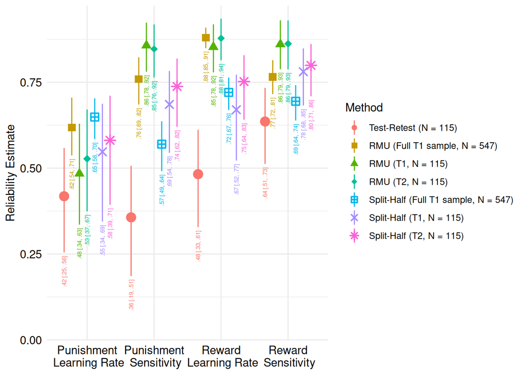

```r
fmt_no_leading_zero = function(x) sub("^(-?)0\\.", "\\1.", sprintf("%.2f", x))

comparison = bind_rows(rmu_retest, testretest, splithalf, rel_full_sample, splithalf_full_sample) %>%
  arrange(parameter, method) |>
  mutate(
    parameter = case_when(
      parameter == "Arew" ~ "Reward\n Learning Rate",
      parameter == "Apun" ~ "Punishment\n Learning Rate",
      parameter == "R"    ~ "Reward\n Sensitivity",
      parameter == "P"    ~ "Punishment\n Sensitivity"
    ),
    is_testretest = grepl("Test-Retest", method),
    method = fct_relevel(method, "Test-Retest (N = 115)"),
    label = paste0(
      fmt_no_leading_zero(estimate), " [",
      fmt_no_leading_zero(lower), ", ",
      fmt_no_leading_zero(upper), "]"
    )
  )

comparison %>%
  ggplot(aes(x = parameter, y = estimate, color = method, shape = method, size = is_testretest)) +
  geom_pointrange(aes(ymin = lower, ymax = upper), position = position_dodge(width = 0.8)) +
  geom_text(
    aes(y = lower, label = label, group = method),
    position = position_dodge(width = 0.8),
    angle = 90, hjust = 1.11, vjust = 0.5,
    size = 2, show.legend = FALSE
  ) +
  scale_shape_manual(values = c(20, 15, 17, 18, 12, 4, 8)) +
  scale_size_manual(values = c(`TRUE` = 1.3, `FALSE` = 0.7), guide = "none") +
  scale_y_continuous(expand = expansion(mult = c(0.25, 0.05))) +
  labs(
    x = NULL,
    y = "Reliability Estimate", color = "Method", shape = "Method",
    title = NULL,
    subtitle = NULL
  ) +
  theme_minimal() +
  theme(
    axis.text = element_text(colour = "black", size = 11),
    axis.title = element_text(size = 11)
    )
```

```r
ggsave("02_pike_reliability_comparson_all.pdf", width = 6.5, height = 4)
```

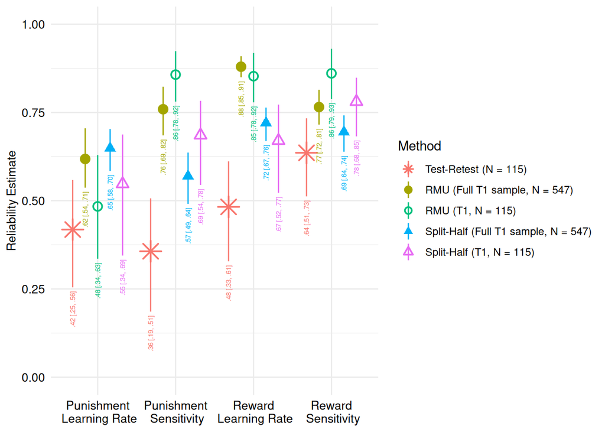

```r
comparison_no_t2 = comparison %>%
  filter(!grepl("T2", method)) %>%
  mutate(method = fct_drop(method))

comparison_no_t2 %>%
  ggplot(aes(x = parameter, y = estimate, color = method, shape = method, size = is_testretest)) +
  geom_pointrange(aes(ymin = lower, ymax = upper), position = position_dodge(width = 0.8)) +
  geom_text(
    aes(y = lower, label = label, group = method),
    position = position_dodge(width = 0.8),
    angle = 90, hjust = 1.11, vjust = 0.5,
    size = 2, show.legend = FALSE
  ) +
  scale_shape_manual(values = c(8, 19, 1, 17, 24, 4, 8)) +
  scale_size_manual(values = c(`TRUE` = 1.3, `FALSE` = 0.7), guide = "none") +
  scale_y_continuous(lim = c(0,1)) +
  labs(
    x = NULL,
    y = "Reliability Estimate", color = "Method", shape = "Method",
    title = NULL,
    subtitle = NULL
  ) +
  theme_minimal() +
  theme(
    axis.text = element_text(colour = "black", size = 10),
    axis.title = element_text(size = 10)
    )
```

```r
ggsave("02_pike_reliability_comparson_no_t2.png", width = 7.2, height = 4.2, dpi = 600)
```

## Filtering out T2 estimates and small sample RMU/split-half estimates.

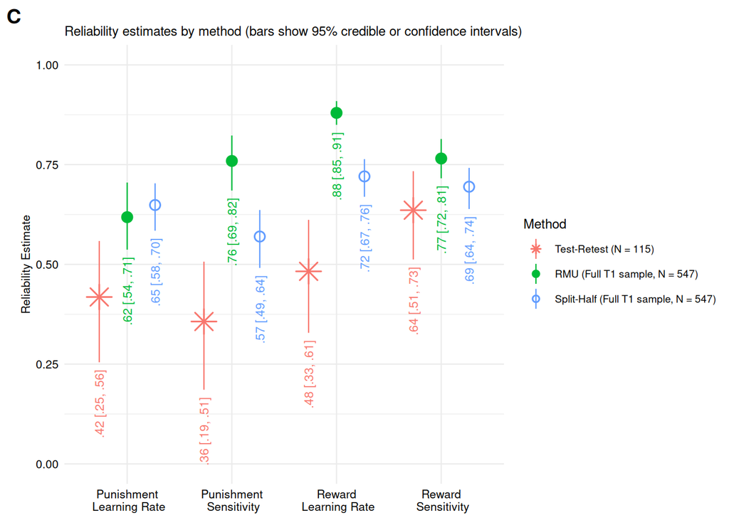

```r
comparison_no_t2 = comparison %>%
  filter(!grepl("T2", method)) %>%
  filter(!grepl("T1, N = 115", method)) %>%
  mutate(method = fct_drop(method))

comparison_no_t2 %>%
  ggplot(aes(x = parameter, y = estimate, color = method, shape = method, size = is_testretest)) +
  geom_pointrange(aes(ymin = lower, ymax = upper), position = position_dodge(width = 0.8)) +
  geom_text(
    aes(y = lower, label = label, group = method),
    position = position_dodge(width = 0.8),
    angle = 90, hjust = 1.11, vjust = 0.5,
    size = 3, show.legend = FALSE
  ) +
  scale_shape_manual(values = c(8, 19, 1, 17, 24, 4, 8)) +
  scale_size_manual(values = c(`TRUE` = 1.3, `FALSE` = 0.7), guide = "none") +
  scale_y_continuous(lim = c(0,1)) +
  labs(
    title = "Reliability estimates by method (bars show 95% credible or confidence intervals)",
    x = NULL,
    y = "Reliability Estimate", color = "Method", shape = "Method",
    tag = "C"
  ) +
  theme_minimal(base_size = 9) +
  theme(
    plot.title = element_text(size = 9),
    axis.text  = element_text(colour = "black", size = 8),
    axis.title = element_text(size = 8),
    plot.tag   = element_text(size = 14, face = "bold")
    )
```

```r
ggsave("02_pike_reliability_comparson_no_t2ort1.png", width = 7, height = 4, dpi = 800)
```

# Communicating uncertainty in RMU

A single point estimate and interval for RMU can undersell how much uncertainty there is about whether a parameter’s reliability is actually good enough to use. Since RMU itself has a full posterior distribution (`rel$reliability_posterior_draws`), we can instead ask what proportion of that posterior falls in conventional “poor” (< .6), “okay” (.6-.8), and “good” (> .8) reliability bands. We do this for the T1 RMU estimates from the full sample (N = 547) computed above.

```r
rmu_band_breaks = c(-Inf, 0.6, 0.8, Inf)
rmu_band_labels = c("Poor (< .6)", "Okay (.6-.8)", "Good (> .8)")

extract_rmu_draws = function(fit, ids, session_label, pars = subj_pars) {
  map_dfr(pars, function(p) {
    rel = rmu(get_draws_matrix(fit, ids, p))
    tibble(
      parameter = p,
      method    = session_label,
      rmu_draw  = rel$reliability_posterior_draws
    )
  })
}

rmu_draws_full_sample = extract_rmu_draws(
  fit_bandit_all, ids_all, paste0("Full T1 sample, N = ", length(ids_all))
) %>%
  mutate(band = cut(rmu_draw, breaks = rmu_band_breaks, labels = rmu_band_labels, right = FALSE))
```

## Table: posterior probability RMU falls in each band

```r
rmu_band_table = rmu_draws_full_sample %>%
  count(parameter, band) %>%
  group_by(parameter) %>%
  mutate(proportion = n / sum(n)) %>%
  ungroup() %>%
  select(-n) %>%
  pivot_wider(names_from = band, values_from = proportion, values_fill = 0) %>%
  mutate(
    parameter = case_when(
      parameter == "Arew" ~ "Reward Learning Rate",
      parameter == "Apun" ~ "Punishment Learning Rate",
      parameter == "R"    ~ "Reward Sensitivity",
      parameter == "P"    ~ "Punishment Sensitivity"
    )
  ) %>%
  select(parameter, all_of(rmu_band_labels))

rmu_band_table %>%
  gt() %>%
  fmt_percent(columns = all_of(rmu_band_labels), decimals = 1) %>%
  data_color(
    columns = all_of(rmu_band_labels),
    fn = scales::col_numeric(palette = c("#f8d7da", "#fff3cd", "#d4edda"), domain = c(0, 1))
  ) %>%
  cols_label(parameter = "Parameter") %>%
  tab_header(
    title = "Posterior probability RMU falls in each reliability band",
    subtitle = paste0("T1, full sample, N = ", length(ids_all))
  )
```

Posterior probability RMU falls in each reliability band

T1, full sample, N = 547

| Parameter | Poor (< .6) | Okay (.6-.8) | Good (> .8) |
| --- | --- | --- | --- |
| Punishment Learning Rate | 34.1% | 66.0% | 0.0% |
| Reward Learning Rate | 0.0% | 0.0% | 100.0% |
| Punishment Sensitivity | 0.0% | 88.0% | 12.0% |
| Reward Sensitivity | 0.0% | 92.1% | 7.9% |

## Plot: posterior density of RMU, shaded by band

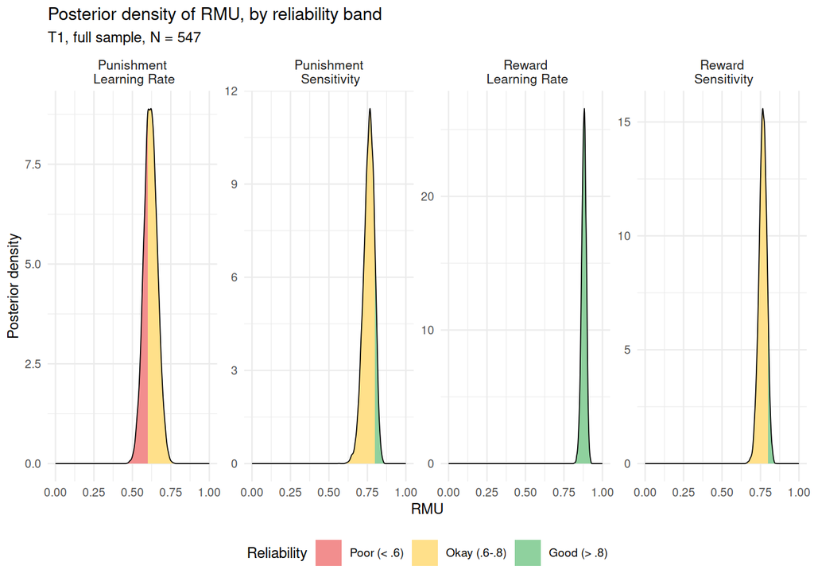

```r
compute_band_density = function(draws, breaks = rmu_band_breaks, labels = rmu_band_labels, n = 512) {
  d = density(draws, from = 0, to = 1, n = n)
  tibble(x = d$x, y = d$y) %>%
    mutate(band = cut(x, breaks = breaks, labels = labels, right = FALSE))
}

rmu_density_df = rmu_draws_full_sample %>%
  group_by(parameter) %>%
  group_modify(~ compute_band_density(.x$rmu_draw)) %>%
  ungroup() %>%
  mutate(
    parameter = case_when(
      parameter == "Arew" ~ "Reward\n Learning Rate",
      parameter == "Apun" ~ "Punishment\n Learning Rate",
      parameter == "R"    ~ "Reward\n Sensitivity",
      parameter == "P"    ~ "Punishment\n Sensitivity"
    )
  )

rmu_density_df %>%
  ggplot(aes(x = x, y = y)) +
  geom_area(aes(fill = band), position = "identity", color = NA) +
  geom_line(aes(group = parameter), color = "black", linewidth = 0.3) +
  facet_wrap(~parameter, nrow = 1, scales = "free_y") +
  scale_fill_manual(values = c(
    "Poor (< .6)"  = "#f28e8e",
    "Okay (.6-.8)" = "#ffe08a",
    "Good (> .8)"  = "#8fd19e"
  )) +
  labs(
    title = "Posterior density of RMU, by reliability band",
    subtitle = paste0("T1, full sample, N = ", length(ids_all)),
    x = "RMU", y = "Posterior density", fill = "Reliability"
  ) +
  theme_minimal(base_size = 9) +
  theme(
    legend.position = "bottom",
    strip.text      = element_text(size = 8)
  )
```

```r
ggsave("02_pike_rmu_density_bands.png", width = 7.5, height = 3, dpi = 800)
```

## Does rescaling parameters change reliability estimates?

RMU (like an ICC) is not guaranteed to be invariant to nonlinear reparameterisations, even monotonic ones. Every subject-level parameter here is generated by pushing an unconstrained, approximately-normal quantity through $\Phi(\cdot)$ (see the hierarchical priors above): $\alpha^r_i = \Phi(\mu_1 + \sigma_1 z^r_i)$, $\alpha^p_i = \Phi(\mu_2 + \sigma_2 z^p_i)$, and $R_i, P_i = 30 \cdot \Phi(\mu_j + \sigma_j z_i)$. Below we invert that transform – dividing the sensitivities by 30 first to bring them back onto $(0,1)$, then applying the normal inverse CDF (`qnorm()`) to every posterior draw of every parameter – to recover an estimate of each subject’s posterior draws on the original unconstrained (probit) scale, and check whether RMU computed on that scale differs from RMU computed on the native $(0,1)$/$(0,30)$ scale. We use the full T1 sample (N = 547) throughout.

```r
transform_draws_matrix = function(fit, ids, par, eps = 1e-6) {
  m = get_draws_matrix(fit, ids, par) # N x draws, native scale
  if (par %in% c("R", "P")) m = m / 30 # bring sensitivities onto (0, 1) first
  m = pmin(pmax(m, eps), 1 - eps) # a handful of draws hit exactly 0/1 (Phi_approx saturation) -> qnorm(0/1) = +-Inf
  qnorm(m) # normal inverse CDF -> unconstrained (probit) scale
}
```

### Posterior densities on the probit scale

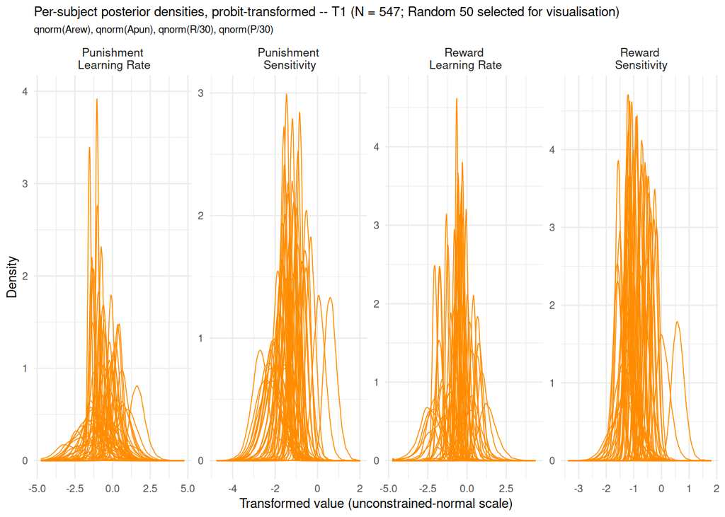

```r
# subset to the plotting subjects BEFORE pivoting long -- pivoting all N = 547
# subjects x ~4000 draws x 4 parameters first (then filtering) is needlessly slow
get_draws_long_transformed = function(fit, ids, plot_ids, pars = subj_pars) {
  map_dfr(pars, function(p) {
    m = transform_draws_matrix(fit, ids, p) # N x draws, probit scale, rownames = ids
    m = m[plot_ids, , drop = FALSE]
    as_tibble(m) %>%
      mutate(id = plot_ids, parameter = p) %>%
      pivot_longer(-c(id, parameter), names_to = "draw", values_to = "value")
  })
}

plot_ids = ids_all[1:50] # same 50 subjects as the untransformed posterior plot above

draws_long_z = get_draws_long_transformed(fit_bandit_all, ids_all, plot_ids, subj_pars) %>%
  mutate(
    parameter = case_when(
      parameter == "Arew" ~ "Reward\n Learning Rate",
      parameter == "Apun" ~ "Punishment\n Learning Rate",
      parameter == "R"    ~ "Reward\n Sensitivity",
      parameter == "P"    ~ "Punishment\n Sensitivity"
    )
  )

y_scales_z = draws_long_z %>%
  group_by(parameter, id) %>%
  summarise(peak = max(density(value)$y), .groups = "drop") %>%
  group_by(parameter) %>%
  summarise(ymax = min(max(peak), 20), .groups = "drop") %>%
  arrange(parameter) %>%
  pull(ymax) %>%
  purrr::map(~ scale_y_continuous(limits = c(0, .x)))

draws_long_z %>%
  ggplot(aes(x = value, group = id)) +
  geom_density(alpha = 0.1, linewidth = 0.3, color = "darkorange") +
  facet_wrap(~parameter, scales = "free", nrow = 1) +
  ggh4x::facetted_pos_scales(y = y_scales_z) +
  labs(
    title = paste0("Per-subject posterior densities, probit-transformed -- T1 (N = ", length(ids_all), "; Random 50 selected for visualisation)"),
    subtitle = "qnorm(Arew), qnorm(Apun), qnorm(R/30), qnorm(P/30)",
    x = "Transformed value (unconstrained-normal scale)", y = "Density"
  ) +
  theme_minimal(base_size = 9) +
  theme(
    plot.title    = element_text(size = 9),
    plot.subtitle = element_text(size = 7),
    strip.text    = element_text(size = 8)
  )
```

```r
ggsave("02_pike_posteriors_transformed.png", width = 7, height = 2.5, dpi = 800)
```

### RMU on the probit-transformed scale

```r
extract_rmu_transformed = function(fit, ids, session_label, pars = subj_pars) {
  map_dfr(pars, function(p) {
    m   = transform_draws_matrix(fit, ids, p)
    rel = rmu(m)
    tibble(
      parameter = p,
      method    = paste0("RMU, probit-transformed (", session_label, ")"),
      estimate  = rel$hdci$rmu_estimate,
      se        = sd(rel$reliability_posterior_draws),
      lower     = rel$hdci$hdci_lowerbound,
      upper     = rel$hdci$hdci_upperbound,
      width     = rel$hdci$hdci_upperbound - rel$hdci$hdci_lowerbound
    )
  })
}

rmu_transformed_full_sample = extract_rmu_transformed(
  fit_bandit_all, ids_all, paste0("Full T1 sample, N = ", length(ids_all))
)

rmu_transformed_full_sample |>
  gt() |>
  fmt_number(decimals = 3)
```

| parameter | method | estimate | se | lower | upper | width |
| --- | --- | --- | --- | --- | --- | --- |
| Arew | RMU, probit-transformed (Full T1 sample, N = 547) | 0.820 | 0.019 | 0.783 | 0.858 | 0.074 |
| Apun | RMU, probit-transformed (Full T1 sample, N = 547) | 0.571 | 0.044 | 0.484 | 0.655 | 0.171 |
| R | RMU, probit-transformed (Full T1 sample, N = 547) | 0.696 | 0.027 | 0.638 | 0.745 | 0.107 |
| P | RMU, probit-transformed (Full T1 sample, N = 547) | 0.670 | 0.043 | 0.584 | 0.747 | 0.163 |

### Comparison: native scale vs. probit-transformed scale

`rel_full_sample` (native-scale RMU on the full T1 sample) was computed above.

```r
rmu_scale_comparison = bind_rows(
  rel_full_sample %>% mutate(scale = "Native scale"),
  rmu_transformed_full_sample %>% mutate(scale = "Probit-transformed (qnorm)")
) %>%
  mutate(
    parameter = case_when(
      parameter == "Arew" ~ "Reward Learning Rate",
      parameter == "Apun" ~ "Punishment Learning Rate",
      parameter == "R"    ~ "Reward Sensitivity",
      parameter == "P"    ~ "Punishment Sensitivity"
    )
  ) %>%
  select(parameter, scale, estimate, se, lower, upper, width) %>%
  arrange(parameter, scale)

rmu_scale_comparison |>
  gt() |>
  fmt_number(decimals = 3)
```

| parameter | scale | estimate | se | lower | upper | width |
| --- | --- | --- | --- | --- | --- | --- |
| Punishment Learning Rate | Native scale | 0.618 | 0.043 | 0.537 | 0.705 | 0.168 |
| Punishment Learning Rate | Probit-transformed (qnorm) | 0.571 | 0.044 | 0.484 | 0.655 | 0.171 |
| Punishment Sensitivity | Native scale | 0.759 | 0.036 | 0.685 | 0.823 | 0.138 |
| Punishment Sensitivity | Probit-transformed (qnorm) | 0.670 | 0.043 | 0.584 | 0.747 | 0.163 |
| Reward Learning Rate | Native scale | 0.880 | 0.015 | 0.850 | 0.909 | 0.060 |
| Reward Learning Rate | Probit-transformed (qnorm) | 0.820 | 0.019 | 0.783 | 0.858 | 0.074 |
| Reward Sensitivity | Native scale | 0.765 | 0.026 | 0.716 | 0.814 | 0.099 |
| Reward Sensitivity | Probit-transformed (qnorm) | 0.696 | 0.027 | 0.638 | 0.745 | 0.107 |

[figure not shown]

```r
rmu_scale_comparison %>%
  ggplot(aes(x = parameter, y = estimate, color = scale, shape = scale)) +
  geom_pointrange(aes(ymin = lower, ymax = upper), position = position_dodge(width = 0.4)) +
  scale_y_continuous(limits = c(0, 1)) +
  labs(
    title = "RMU: native scale vs. probit-transformed parameters",
    subtitle = paste0("Full T1 sample, N = ", length(ids_all)),
    x = NULL, y = "RMU estimate", color = "Scale", shape = "Scale"
  ) +
  theme_minimal() +
  theme(
    axis.text  = element_text(colour = "black", size = 10),
    axis.title = element_text(size = 10)
  )
```

```r
ggsave("02_pike_rmu_scale_comparison.png", width = 6.5, height = 4, dpi = 600)
```

# Appendix: the Stan model

## Source

The stan model used to fit the Bayesian models is `bandit4arm_4par.stan`, shipped inside the `hBayesDM` package (`system.file("stan_files", "bandit4arm_4par.stan", package = "hBayesDM")`) and printed in full below:

```stan
/*
    hBayesDM is free software: you can redistribute it and/or modify
    it under the terms of the GNU General Public License as published by
    the Free Software Foundation, either version 3 of the License, or
    (at your option) any later version.

    hBayesDM is distributed in the hope that it will be useful,
    but WITHOUT ANY WARRANTY; without even the implied warranty of
    MERCHANTABILITY or FITNESS FOR A PARTICULAR PURPOSE.  See the
    GNU General Public License for more details.

    You should have received a copy of the GNU General Public License
    along with hBayesDM.  If not, see <http://www.gnu.org/licenses/>.
*/

// Seymour et al 2012 J neuro model, w/o C (chioce perseveration)
data {
  int<lower=1> N;
  int<lower=1> T;
  array[N] int<lower=1, upper=T> Tsubj;
  array[N, T] real rew;
  array[N, T] real los;
  array[N, T] int choice;
}
transformed data {
  vector[4] initV;
  initV = rep_vector(0.0, 4);
}
parameters {
  // Declare all parameters as vectors for vectorizing
  // Hyper(group)-parameters
  vector[4] mu_pr;
  vector<lower=0>[4] sigma;

  // Subject-level raw parameters (for Matt trick)
  vector[N] Arew_pr;
  vector[N] Apun_pr;
  vector[N] R_pr;
  vector[N] P_pr;
}
transformed parameters {
  // Transform subject-level raw parameters
  vector<lower=0, upper=1>[N] Arew;
  vector<lower=0, upper=1>[N] Apun;
  vector<lower=0, upper=30>[N] R;
  vector<lower=0, upper=30>[N] P;

  for (i in 1 : N) {
    Arew[i] = Phi_approx(mu_pr[1] + sigma[1] * Arew_pr[i]);
    Apun[i] = Phi_approx(mu_pr[2] + sigma[2] * Apun_pr[i]);
    R[i] = Phi_approx(mu_pr[3] + sigma[3] * R_pr[i]) * 30;
    P[i] = Phi_approx(mu_pr[4] + sigma[4] * P_pr[i]) * 30;
  }
}
model {
  // Hyperparameters
  mu_pr ~ normal(0, 1);
  sigma ~ normal(0, 0.2);

  // individual parameters
  Arew_pr ~ normal(0, 1.0);
  Apun_pr ~ normal(0, 1.0);
  R_pr ~ normal(0, 1.0);
  P_pr ~ normal(0, 1.0);

  for (i in 1 : N) {
    // Define values
    vector[4] Qr;
    vector[4] Qp;
    vector[4] PEr_fic; // prediction error - for reward fictive updating (for unchosen options)
    vector[4] PEp_fic; // prediction error - for punishment fictive updating (for unchosen options)
    vector[4] Qsum; // Qsum = Qrew + Qpun + perseverance

    real Qr_chosen;
    real Qp_chosen;
    real PEr; // prediction error - for reward of the chosen option
    real PEp; // prediction error - for punishment of the chosen option

    // Initialize values
    Qr = initV;
    Qp = initV;
    Qsum = initV;

    for (t in 1 : Tsubj[i]) {
      // softmax choice
      choice[i, t] ~ categorical_logit(Qsum);

      // Prediction error signals
      PEr = R[i] * rew[i, t] - Qr[choice[i, t]];
      PEp = P[i] * los[i, t] - Qp[choice[i, t]];
      PEr_fic = -Qr;
      PEp_fic = -Qp;

      // store chosen deck Q values (rew and pun)
      Qr_chosen = Qr[choice[i, t]];
      Qp_chosen = Qp[choice[i, t]];

      // First, update Qr & Qp for all decks w/ fictive updating
      Qr += Arew[i] * PEr_fic;
      Qp += Apun[i] * PEp_fic;
      // Replace Q values of chosen deck with correct values using stored values
      Qr[choice[i, t]] = Qr_chosen + Arew[i] * PEr;
      Qp[choice[i, t]] = Qp_chosen + Apun[i] * PEp;

      // Q(sum)
      Qsum = Qr + Qp;
    }
  }
}
generated quantities {
  // For group level parameters
  real<lower=0, upper=1> mu_Arew;
  real<lower=0, upper=1> mu_Apun;
  real<lower=0, upper=30> mu_R;
  real<lower=0, upper=30> mu_P;

  // For log likelihood calculation
  array[N] real log_lik;

  // For posterior predictive check
  array[N, T] real y_pred;

  // Set all posterior predictions to 0 (avoids NULL values)
  for (i in 1 : N) {
    for (t in 1 : T) {
      y_pred[i, t] = -1;
    }
  }

  mu_Arew = Phi_approx(mu_pr[1]);
  mu_Apun = Phi_approx(mu_pr[2]);
  mu_R = Phi_approx(mu_pr[3]) * 30;
  mu_P = Phi_approx(mu_pr[4]) * 30;

  {
    // local section, this saves time and space
    for (i in 1 : N) {
      // Define values
      vector[4] Qr;
      vector[4] Qp;
      vector[4] PEr_fic; // prediction error - for reward fictive updating (for unchosen options)
      vector[4] PEp_fic; // prediction error - for punishment fictive updating (for unchosen options)
      vector[4] Qsum; // Qsum = Qrew + Qpun + perseverance

      real Qr_chosen;
      real Qp_chosen;
      real PEr; // prediction error - for reward of the chosen option
      real PEp; // prediction error - for punishment of the chosen option

      // Initialize values
      Qr = initV;
      Qp = initV;
      Qsum = initV;
      log_lik[i] = 0.0;

      for (t in 1 : Tsubj[i]) {
        // compute log likelihood of current trial
        log_lik[i] += categorical_logit_lpmf(choice[i, t] | Qsum);

        // generate posterior prediction for current trial
        y_pred[i, t] = categorical_rng(softmax(Qsum));

        // Prediction error signals
        PEr = R[i] * rew[i, t] - Qr[choice[i, t]];
        PEp = P[i] * los[i, t] - Qp[choice[i, t]];
        PEr_fic = -Qr;
        PEp_fic = -Qp;

        // store chosen deck Q values (rew and pun)
        Qr_chosen = Qr[choice[i, t]];
        Qp_chosen = Qp[choice[i, t]];

        // First, update Qr & Qp for all decks w/ fictive updating
        Qr += Arew[i] * PEr_fic;
        Qp += Apun[i] * PEp_fic;
        // Replace Q values of chosen deck with correct values using stored values
        Qr[choice[i, t]] = Qr_chosen + Arew[i] * PEr;
        Qp[choice[i, t]] = Qp_chosen + Apun[i] * PEp;

        // Q(sum)
        Qsum = Qr + Qp;
      }
    }
  }
}
```

## Model description

**Task**: A hierarchical Rescorla-Wagner learner for a 4-armed bandit, where each arm can independently deliver a reward and a punishment on the same trial (Seymour et al., [2012](https://www.jneurosci.org/content/32/17/5833)).

**Notation**: Subjects are indexed $i = 1, \dots, N$, trials $t = 1, \dots, T_i$ (the number of trials subject $i$ actually completed) and arms $k \in \{1, 2, 3, 4\}$. On trial $t$, subject $i$ chooses arm $c_{it} \in \{1, 2, 3, 4\}$ and then observes a reward $\text{rew}_{it} \in \{0, 1\}$ and a punishment $\text{pun}_{it} \in \{0, -1\}$. These are the `gain` and `loss` columns built by `bandit4arm_df()` (see above); `hBayesDM` flips the sign of `loss` internally so that punishments enter the model as negative numbers.

**Parameters**: Every subject gets their own

- $\alpha^{r}_i$ – reward learning rate (`Arew`)
- $\alpha^{p}_i$ – punishment learning rate (`Apun`)
- $R_i$ – reward sensitivity (`R`), i.e. how much subject $i$ likes reward
- $P_i$ – punishment sensitivity (`P`), i.e. how much subject $i$ dislikes punishment

**Latent values**: Each subject carries two separate expectations for every arm: a reward expectation $Q^{r}_{itk}$ and a punishment expectation $Q^{p}_{itk}$. Choices are driven by their sum, the *net* value of each arm:

$$Q^{\Sigma}_{itk} = Q^{r}_{itk} + Q^{p}_{itk}$$

### Choice rule

On every trial the choice is a softmax over the four net values:

$$c_{it} \sim \text{Categorical}\left(\pi_{it}\right), \qquad
\pi_{itk} = \Pr\left(c_{it} = k\right) = \frac{\exp\left(Q^{\Sigma}_{itk}\right)}{\sum_{j=1}^{4} \exp\left(Q^{\Sigma}_{itj}\right)}$$

Note there is no separate inverse-temperature parameter: because $R_i$ and $P_i$ scale the magnitude of the $Q$ values (see the prediction errors below), they also set how deterministic a subject’s choices are.

### Initial values

At the start of the task all expectations are zero,

$$Q^{r}_{i1k} = Q^{p}_{i1k} = 0 \qquad \text{for all } k,$$

so the first choice is made at random ($\pi_{i1k} = 1/4$ for every arm).

### Prediction errors for the chosen arm

After choosing arm $c_{it}$ and observing the outcome, the subject computes a reward prediction error and a punishment prediction error for that arm only:

$$\begin{aligned}
\text{PE}^{r}_{it} &= R_i \cdot \text{rew}_{it} - Q^{r}_{i t c_{it}} \\
\text{PE}^{p}_{it} &= P_i \cdot \text{pun}_{it} - Q^{p}_{i t c_{it}}
\end{aligned}$$

Each is the outcome actually received (scaled by the subject’s sensitivity) minus what was expected for the chosen arm. Scaling the raw outcome by $R_i$ or $P_i$ is how the model accounts for individual differences in the overall impact of rewards and punishments: a subject with a large $R_i$ experiences a larger reward prediction error from the same win than a subject with a small $R_i$.

### Fictive prediction errors for the unchosen arms

The unchosen arms are also updated on every trial, as if they had been chosen and delivered *no* reward and *no* punishment (fictive, or counterfactual, updating). Their prediction errors are therefore the negative of the current expectation, for every arm $k$:

$$\begin{aligned}
\text{PEF}^{r}_{itk} &= 0 - Q^{r}_{itk} \\
\text{PEF}^{p}_{itk} &= 0 - Q^{p}_{itk}
\end{aligned}$$

### Value updating

The expectations carried into the next trial are updated Rescorla-Wagner style, with separate learning rates for reward and punishment. For the chosen arm ($k = c_{it}$):

$$\begin{aligned}
Q^{r}_{i,t+1,k} &= Q^{r}_{itk} + \alpha^{r}_i \cdot \text{PE}^{r}_{it} \\
Q^{p}_{i,t+1,k} &= Q^{p}_{itk} + \alpha^{p}_i \cdot \text{PE}^{p}_{it}
\end{aligned}$$

For every unchosen arm ($k \neq c_{it}$):

$$\begin{aligned}
Q^{r}_{i,t+1,k} &= Q^{r}_{itk} + \alpha^{r}_i \cdot \text{PEF}^{r}_{itk} = \left(1 - \alpha^{r}_i\right) Q^{r}_{itk} \\
Q^{p}_{i,t+1,k} &= Q^{p}_{itk} + \alpha^{p}_i \cdot \text{PEF}^{p}_{itk} = \left(1 - \alpha^{p}_i\right) Q^{p}_{itk}
\end{aligned}$$

i.e. every unchosen arm’s reward and punishment expectations decay a fraction $\alpha^{r}_i$ and $\alpha^{p}_i$ of the way back toward zero on every trial. (In the Stan code the fictive update is applied to all four arms first and the chosen arm’s entry is then overwritten with the real update; the result is exactly the two cases above.)

This makes sense for the fluctuating bandit task because the reward and punishment probabilities change over time - so that prior knowledge is less useful.

### Hierarchical priors (non-centred parameterisation)

All four subject-level parameters are bounded ($\alpha^{r}_i, \alpha^{p}_i \in [0, 1]$ and $R_i, P_i \in [0, 30]$) but are not sampled on those scales directly. Instead each subject gets an unconstrained standard-normal score $z_i$, the population location $\mu$ and scale $\sigma$ are applied on that unconstrained scale, and the result is pushed through the standard normal CDF $\Phi(\cdot)$ (Stan’s `Phi_approx()`, a fast approximation) to land in $(0, 1)$, then stretched by 30 for the two sensitivities:

$$\begin{aligned}
\alpha^{r}_i &= \Phi\left(\mu_1 + \sigma_1 \, z^{r}_i\right) \\
\alpha^{p}_i &= \Phi\left(\mu_2 + \sigma_2 \, z^{p}_i\right) \\
R_i &= 30 \cdot \Phi\left(\mu_3 + \sigma_3 \, z^{R}_i\right) \\
P_i &= 30 \cdot \Phi\left(\mu_4 + \sigma_4 \, z^{P}_i\right)
\end{aligned}$$

with priors

$$\begin{aligned}
z^{r}_i, \; z^{p}_i, \; z^{R}_i, \; z^{P}_i &\sim \mathcal{N}(0, 1) \\
\mu_j &\sim \mathcal{N}(0, 1) \\
\sigma_j &\sim \mathcal{N}^{+}(0, 0.2)
\end{aligned}
\qquad j = 1, \dots, 4$$

$\mu$ (`mu_pr`) and $\sigma$ (`sigma`) are therefore the population mean and SD on the **probit scale**, not on the learning-rate/sensitivity scale – $\mu_1 = 0$ means a population centred on $\alpha^{r} = 0.5$, and to read $\sigma$ you have to push it through $\Phi$ too. The half-normal $\sigma_j \sim \mathcal{N}^{+}(0, 0.2)$ is hBayesDM’s own prior for this model, the same tightened-sigma fix this project’s earlier custom model needed to hand-add for its own convergence problems.

### Mapping between the equations and the Stan code

| Equation | Stan | Meaning |
| --- | --- | --- |
| $c_{it}$ | `choice[i, t]` | arm chosen (1-4) |
| $\text{rew}_{it}$ | `rew[i, t]` | reward on that trial (`gain` column; 1 or 0) |
| $\text{pun}_{it}$ | `los[i, t]` | punishment on that trial, `-abs(loss)` (0 or -1) |
| $T_i$ | `Tsubj[i]` | trials completed by subject $i$ |
| $Q^{r}_{it \cdot}$, $Q^{p}_{it \cdot}$, $Q^{\Sigma}_{it \cdot}$ | `Qr`, `Qp`, `Qsum` | reward / punishment / net expectations, all four arms |
| $\text{PE}^{r}_{it}$, $\text{PE}^{p}_{it}$ | `PEr`, `PEp` | prediction errors, chosen arm |
| $\text{PEF}^{r}_{it \cdot}$, $\text{PEF}^{p}_{it \cdot}$ | `PEr_fic`, `PEp_fic` | fictive prediction errors, all four arms |
| $\alpha^{r}_i$, $\alpha^{p}_i$ | `Arew[i]`, `Apun[i]` | reward / punishment learning rates |
| $R_i$, $P_i$ | `R[i]`, `P[i]` | reward / punishment sensitivities |
| $z^{r}_i$, $z^{p}_i$, $z^{R}_i$, $z^{P}_i$ | `Arew_pr[i]`, `Apun_pr[i]`, `R_pr[i]`, `P_pr[i]` | subject-level standard-normal scores |
| $\mu_j$, $\sigma_j$ | `mu_pr[j]`, `sigma[j]` | population mean / SD on the probit scale |